# HW4

2024-12-06

財務指標資料分析 Analysis of financial indexes

分析財務報表，了解公司企業特性，以降維的方式，找出有意義的指標，衡量績優公司。

資料financialdata_20231113.csv有382間公司的財務指標。此數據集包含了重點財務指標，如ROE、周轉率和研發投資、 SeasonReturn(%)（季度回報率）、TwoMonthReturn(%)（兩月回報率）、MonthReturn(%)（月回報率）和 WeekReturn(%)（周回報）等。

#1.以PCA或SPCA分析，找出前二個主成份共能解釋多少變異？

我用PCA，前兩個主成分共能解釋的累積變異比例為 41.27%，其中： 第一主成分（PC1）解釋了 22.6% 的變異。 第二主成分（PC2）解釋了 18.67% 的變異。 合計前兩個主成分已捕捉到原始數據中 41.27% 的總變異。

#2.找出前三個主成份分別重點變數為何，需說明你的理由。

pca$rotation表中的各個主成分與原變數的相關性，看圖也可以(但是那個圖的變數都疊在一起了我也不會把它改動態QQ，所以我才看數字)

PC1(利潤相關指標)： By pca$rotation： NetProfitMargin (0.4778) OperatingProfitMargin (0.4679) CapitalExpendituresRatio (0.4042) 變數的係數絕對值較大 → 它們在PC1中的權重最高

PC2(股票或投資回報的短期變化)： By pca$rotation： MonthReturn… (-0.5221) TwoMonthReturn… (-0.5262) SeasonReturn… (-0.5175) 變數的係數絕對值較大 → 它們在PC2中的權重最高

PC3(盈利能力與資產負債效率的平衡)： By pca$rotation： GrossMargin (0.5143) ROE (0.4139) AccountsPayableTurnoverRatio (-0.5876) 變數的係數絕對值較大 → 它們在PC3中的權重最高

```r
#Part0. Preparation
library(readr)
finance <- read_csv("C:/Users/Ava/Desktop/R/HW4/financialdata_20231113.csv")
View(finance)
fin <- finance[,3:18]
library(summarytools)
dfSummary(finance) # provides a detailed summary of your data frame
```

```
## Data Frame Summary
## finance
## Dimensions: 398 x 18
## Duplicates: 16
##
## -------------------------------------------------------------------------------------------------------------------------------------
## No   Variable                          Stats / Values                Freqs (% of Valid)    Graph                 Valid      Missing
## ---- --------------------------------- ----------------------------- --------------------- --------------------- ---------- ---------
## 1    Code                              Mean (sd) : 4368.4 (2329.6)   374 distinct values   : . .     :           398        0
##      [numeric]                         min < med < max:                                    : : : :   :           (100.0%)   (0.0%)
##                                        1102 < 4143.5 < 9962                                : : : : : :
##                                        IQR (CV) : 3738.5 (0.5)                             : : : : : :   :
##                                                                                            : : : : : :   : :
##
## 2    Name                              1. 六方科-KY                    4 ( 1.0%)                                 398        0
##      [character]                       2. 正能量智能                   4 ( 1.0%)                                 (100.0%)   (0.0%)
##                                        3. 名軒                         4 ( 1.0%)
##                                        4. 長佳智能                     4 ( 1.0%)
##                                        5. 飛寶企業                     4 ( 1.0%)
##                                        6. 智晶                         4 ( 1.0%)
##                                        7. 濾能                         4 ( 1.0%)
##                                        8. 騰雲                         4 ( 1.0%)
##                                        9. ABC-KY                       1 ( 0.3%)
##                                        10. AES-KY                      1 ( 0.3%)
##                                        [ 364 others ]                364 (91.5%)           IIIIIIIIIIIIIIIIII
##
## 3    ROE                               Mean (sd) : 0 (0.1)           382 distinct values               : .       398        0
##      [numeric]                         min < med < max:                                                : :       (100.0%)   (0.0%)
##                                        -0.4 < 0 < 0.2                                                  : :
##                                        IQR (CV) : 0 (4)                                                : :
##                                                                                                      . : :
##
## 4    GrossMargin                       Mean (sd) : 0.2 (0.3)         382 distinct values             :           398        0
##      [numeric]                         min < med < max:                                              :           (100.0%)   (0.0%)
##                                        -2.3 < 0.2 < 0.8                                              :
##                                        IQR (CV) : 0.2 (1.1)                                          :
##                                                                                                      : .
##
## 5    OperatingProfitMargin             Mean (sd) : -0.9 (8)          382 distinct values                     :   398        0
##      [numeric]                         min < med < max:                                                      :   (100.0%)   (0.0%)
```

[output cut: 64 more lines]

```
##                                        IQR (CV) : 32.9 (-3.1)                                . : : :
##                                                                                            . : : : : .
##
## 17   MonthReturn...                    Mean (sd) : -7.8 (29.2)       374 distinct values         :               398        0
##      [numeric]                         min < med < max:                                          :               (100.0%)   (0.0%)
##                                        -84.6 < -6 < 135                                        : : .
##                                        IQR (CV) : 32.7 (-3.8)                                . : : :
##                                                                                              : : : : :
##
## 18   WeekReturn...                     Mean (sd) : 3.1 (6.2)         361 distinct values           :             398        0
##      [numeric]                         min < med < max:                                            :             (100.0%)   (0.0%)
##                                        -40.7 < 2.2 < 49                                            :
##                                        IQR (CV) : 3.9 (2)                                          : :
##                                                                                                    : :
## -------------------------------------------------------------------------------------------------------------------------------------
```

```r
view(dfSummary(finance)) # see the results in RStudio’s Viewer; stview(dfSummary(murders))
```

```
## Switching method to 'browser'
## Output file written: C:\Users\Ava\AppData\Local\Temp\RtmpOgfFbt\file1b68642262ac.html
```

```r
library(tidyverse)
finance <- finance |>
  filter(
    !(InventoryTurnover == Inf |
        AccountsPayableTurnoverRatio == Inf |
        AccountsReceivableTurnoverRatio == Inf)
  ) #!用來移除東東
fin <- finance[,3:18]
```

```r
#Part1. Dimension reduction (Correlation)

## understand ur data
M = cor(fin)

## create heatmap for correlation
library(reshape2)
melted_cormat <- melt(M)
head(melted_cormat)
```

```
##                    Var1 Var2      value
## 1                   ROE  ROE  1.0000000
## 2           GrossMargin  ROE  0.4275882
## 3 OperatingProfitMargin  ROE  0.1655295
## 4       NetProfitMargin  ROE  0.1932846
## 5    AssetTurnoverRatio  ROE  0.2633898
## 6     FinancialLeverage  ROE -0.1518323
```

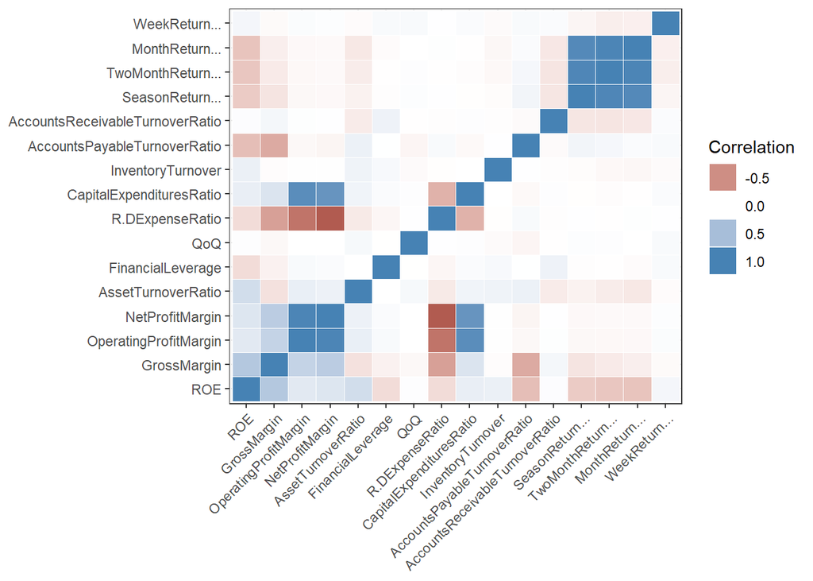

```r
library(ggplot2)
ggplot(data = melted_cormat,
       aes(Var1, Var2)) +
  geom_tile(aes(fill = value), colour = "white") +
  scale_fill_gradient2(low = "firebrick4", high = "steelblue",
                       mid = "white", midpoint = 0) +
  guides(fill=guide_legend(title="Correlation")) +
  theme_bw() +
  theme(axis.text.x = element_text(angle = 45, hjust = 1, vjust = 1),
        axis.title = element_blank())
```